# NFL predictions

# Purpose

The purpose of this project is to predict the winners of a Week of NFL games based on pre-season rankings and scores during the regular season.

The first model to be used is very simple - I use the preseason rankings as prior information, and assign an ability score based on those rankings. Then I use the point spread as data to create a posterior distribution of ability. Finally, I calculate the probability of winning based on the matchup and posterior ability scores.

# Set up

The parameters are as follows

```r
this_week <- 3
```

# Obtaining data

## Preseason rankings

We try to get preseason ranking from [Yahoo](https://sports.yahoo.com/nfl-preseason-power-rankings-2017-133009081.html). It’s a slightly annoying webscraping exercise - on this website the preseason ranks are listed in HTML `h2` headlines, along with other headlines. I used the nifty SelectorGadget that came with the `rvest` package to make this discovery, rather than the developer tools in Microsoft Edge, which are powerful but rather arcane.

```r
preseas_html %>%
  html_nodes(xpath="//h2") %>%
  html_text %>%
  filter(grepl("[:digit:]{1,2}[:alpha:]+"))
```

```
Error in UseMethod("filter_") :
  no applicable method for 'filter_' applied to an object of class "character"
```

```r
preseas_html %>%
  html_nodes(xpath="//h2") %>%
  html_text %>%
  filter(grepl("[:digit:]{1,2}[:alpha:]+",.))
```

```
Error in UseMethod("filter_") :
  no applicable method for 'filter_' applied to an object of class "character"
```

```r
preseas_html %>%
  html_nodes(xpath="//h2") %>%
  html_text %>%
  filter(str_detect("\d{1,2}\w+"))
```

```
Error: '\d' is an unrecognized escape in character string starting ""\d"
```

```r
preseas_html %>%
  html_nodes(xpath="//h2") %>%
  html_text %>%
  filter(str_detect("\\d{1,2}\\w+"))
```

```
Error in UseMethod("filter_") :
  no applicable method for 'filter_' applied to an object of class "character"
```

```r
preseas_html %>%
  html_nodes(xpath="//h2") %>%
  html_text() %>%
  filter(str_detect("\\d{1,2}\\w+"))
```

```
Error in UseMethod("filter_") :
  no applicable method for 'filter_' applied to an object of class "character"
```

```r
preseas_html %>%
  html_nodes(xpath="//h2") %>%
  html_text() %>%
  data_frame() %>%
  filter(str_detect("\\d{1,2}\\w+"))
```

```
Error in filter_impl(.data, quo) :
  Evaluation error: argument "pattern" is missing, with no default.
```

| . |
| --- |
| With the president directly criticizing players, they should no longer be silent |
| NFL preseason power rankings for 2017 |
| 1New England Patriots |
| 2Seattle Seahawks |
| 3Dallas Cowboys |
| 4Pittsburgh Steelers |
| 5Oakland Raiders |
| 6Atlanta Falcons |
| 7Green Bay Packers |
| 8Detroit Lions |

[output cut: 25 more lines]

```r
preseas_html %>%
  html_nodes(xpath="//h2") %>%
  html_text() %>%
  data_frame() %>%
  filter(str_detect("\\d{1,2}\\w+"))
```

```
Error in filter_impl(.data, quo) :
  Evaluation error: argument "pattern" is missing, with no default.
```

| . |
| --- |
| With the president directly criticizing players, they should no longer be silent |
| NFL preseason power rankings for 2017 |
| 1New England Patriots |
| 2Seattle Seahawks |
| 3Dallas Cowboys |
| 4Pittsburgh Steelers |
| 5Oakland Raiders |
| 6Atlanta Falcons |
| 7Green Bay Packers |
| 8Detroit Lions |

[output cut: 25 more lines]

| rank |
| --- |
| With the president directly criticizing players, they should no longer be silent |
| NFL preseason power rankings for 2017 |
| 1New England Patriots |
| 2Seattle Seahawks |
| 3Dallas Cowboys |
| 4Pittsburgh Steelers |
| 5Oakland Raiders |
| 6Atlanta Falcons |
| 7Green Bay Packers |
| 8Detroit Lions |

[output cut: 25 more lines]

| rank |
| --- |

| rank |
| --- |

| rank |
| --- |

| rank |
| --- |
| With the president directly criticizing players, they should no longer be silent |
| NFL preseason power rankings for 2017 |
| 1New England Patriots |
| 2Seattle Seahawks |
| 3Dallas Cowboys |
| 4Pittsburgh Steelers |
| 5Oakland Raiders |
| 6Atlanta Falcons |
| 7Green Bay Packers |
| 8Detroit Lions |

[output cut: 25 more lines]

```r
preseas_html %>%
  html_nodes(xpath="//h2") %>%
  html_text() %>%
  data_frame(rank = .) -> foo %>%
  filter(str_detect(rank,"^\\d+"))
```

```
Error in foo %>% filter(str_detect(rank, "^\\d+")) <- preseas_html %>%  :
  could not find function "%>%<-"
```

| rank |
| --- |
| 1New England Patriots |
| 2Seattle Seahawks |
| 3Dallas Cowboys |
| 4Pittsburgh Steelers |
| 5Oakland Raiders |
| 6Atlanta Falcons |
| 7Green Bay Packers |
| 8Detroit Lions |
| 9New York Giants |
| 10Denver Broncos |

[output cut: 22 more lines]

| rank_text | rank |
| --- | --- |
| 1New England Patriots | 1 |
| 2Seattle Seahawks | 2 |
| 3Dallas Cowboys | 3 |
| 4Pittsburgh Steelers | 4 |
| 5Oakland Raiders | 5 |
| 6Atlanta Falcons | 6 |
| 7Green Bay Packers | 7 |
| 8Detroit Lions | 8 |
| 9New York Giants | 9 |
| 10Denver Broncos | 10 |

[output cut: 22 more lines]

| rank_text | rank | team |
| --- | --- | --- |
| 1New England Patriots | 1 | 1New England Patriots |
| 2Seattle Seahawks | 2 | 2Seattle Seahawks |
| 3Dallas Cowboys | 3 | 3Dallas Cowboys |
| 4Pittsburgh Steelers | 4 | 4Pittsburgh Steelers |
| 5Oakland Raiders | 5 | 5Oakland Raiders |
| 6Atlanta Falcons | 6 | 6Atlanta Falcons |
| 7Green Bay Packers | 7 | 7Green Bay Packers |
| 8Detroit Lions | 8 | 8Detroit Lions |
| 9New York Giants | 9 | 9New York Giants |
| 10Denver Broncos | 10 | 10Denver Broncos |

[output cut: 22 more lines]

| rank_text | rank | team |
| --- | --- | --- |
| 1New England Patriots | 1 | New England Patriots |
| 2Seattle Seahawks | 2 | Seattle Seahawks |
| 3Dallas Cowboys | 3 | Dallas Cowboys |
| 4Pittsburgh Steelers | 4 | Pittsburgh Steelers |
| 5Oakland Raiders | 5 | Oakland Raiders |
| 6Atlanta Falcons | 6 | Atlanta Falcons |
| 7Green Bay Packers | 7 | Green Bay Packers |
| 8Detroit Lions | 8 | Detroit Lions |
| 9New York Giants | 9 | New York Giants |
| 10Denver Broncos | 10 | Denver Broncos |

[output cut: 22 more lines]

```r
preseas_html <- read_html("https://sports.yahoo.com/nfl-preseason-power-rankings-2017-133009081.html")
preseas_html %>%
  html_nodes(xpath="//h2") %>%
  html_text() %>%
  data_frame(rank_text = .)  %>%
  filter(str_detect(rank_text,"^\\d+")) %>%
  mutate(rank = str_extract(rank_text,"^\\d+"),
         team = str_extract(rank_text,"[A-Za-z].+$")) %>%
  select(-rank_text) -> preseason_ranks
preseason_ranks
```

| rank | team |
| --- | --- |
| 1 | New England Patriots |
| 2 | Seattle Seahawks |
| 3 | Dallas Cowboys |
| 4 | Pittsburgh Steelers |
| 5 | Oakland Raiders |
| 6 | Atlanta Falcons |
| 7 | Green Bay Packers |
| 8 | Detroit Lions |
| 9 | New York Giants |
| 10 | Denver Broncos |

[output cut: 22 more lines]

## Scores

Now I get scores. To do this I scrape the [Pro Football Reference](https://www.pro-football-reference.com/years/2017/week_1.htm) site because they seem like they have the easiest layout to scrape and a logical URL structure. I’m also testing out my functional programming skills here. One of the most annoying ugly things about programming has been accumulating data and combining it. The `foreach` package made that more elegant, but `purrr` should make that even better.

```r
week_html <- read_html(url_scrape(week))
```

```
Error in paste0("https://www.pro-football-reference.com/years/", year,  :
  object 'week' not found
```

```r
week_html %>%
  html_nodes(".teams") %>%
  html_text %>%
  data_frame(score_text=.) %>%
  mutate(score_text = str_replace("[\\n\\t]+","|"))
```

```
Error in mutate_impl(.data, dots) :
  Evaluation error: argument "replacement" is missing, with no default.
```

```r
week_html %>%
  html_nodes(".teams") %>%
  html_text %>%
  data_frame(score_text=.) %>%
  mutate(score_text = str_replace_all("[\\n\\t]+","|"))
```

```
Error in mutate_impl(.data, dots) :
  Evaluation error: argument "replacement" is missing, with no default.
```

| score_text |
| --- |
| Sep 7, 2017Kansas City Chiefs\|42\|Final\|New England Patriots\|27\| \| |
| Sep 10, 2017Pittsburgh Steelers\|21\|Final\|Cleveland Browns\|18\| \| |
| Sep 10, 2017Baltimore Ravens\|20\|Final\|Cincinnati Bengals\|0\| \| |
| Sep 10, 2017Atlanta Falcons\|23\|Final\|Chicago Bears\|17\| \| |
| Sep 10, 2017Philadelphia Eagles\|30\|Final\|Washington Redskins\|17\| \| |
| Sep 10, 2017New York Jets\|12\|Final\|Buffalo Bills\|21\| \| |
| Sep 10, 2017Oakland Raiders\|26\|Final\|Tennessee Titans\|16\| \| |
| Sep 10, 2017Jacksonville Jaguars\|29\|Final\|Houston Texans\|7\| \| |
| Sep 10, 2017Arizona Cardinals\|23\|Final\|Detroit Lions\|35\| \| |
| Sep 10, 2017Indianapolis Colts\|9\|Final\|Los Angeles Rams\|46\| \| |

[output cut: 5 more lines]

| score_text |
| --- |
| Kansas City Chiefs\|42\|Final\|New England Patriots\|27\| \| |
| Pittsburgh Steelers\|21\|Final\|Cleveland Browns\|18\| \| |
| Baltimore Ravens\|20\|Final\|Cincinnati Bengals\|0\| \| |
| Atlanta Falcons\|23\|Final\|Chicago Bears\|17\| \| |
| Philadelphia Eagles\|30\|Final\|Washington Redskins\|17\| \| |
| New York Jets\|12\|Final\|Buffalo Bills\|21\| \| |
| Oakland Raiders\|26\|Final\|Tennessee Titans\|16\| \| |
| Jacksonville Jaguars\|29\|Final\|Houston Texans\|7\| \| |
| Arizona Cardinals\|23\|Final\|Detroit Lions\|35\| \| |
| Indianapolis Colts\|9\|Final\|Los Angeles Rams\|46\| \| |

[output cut: 5 more lines]

| score_text | week |
| --- | --- |
| Kansas City Chiefs\|42\|Final\|New England Patriots\|27\| \| | 1 |
| Pittsburgh Steelers\|21\|Final\|Cleveland Browns\|18\| \| | 1 |
| Baltimore Ravens\|20\|Final\|Cincinnati Bengals\|0\| \| | 1 |
| Atlanta Falcons\|23\|Final\|Chicago Bears\|17\| \| | 1 |
| Philadelphia Eagles\|30\|Final\|Washington Redskins\|17\| \| | 1 |
| New York Jets\|12\|Final\|Buffalo Bills\|21\| \| | 1 |
| Oakland Raiders\|26\|Final\|Tennessee Titans\|16\| \| | 1 |
| Jacksonville Jaguars\|29\|Final\|Houston Texans\|7\| \| | 1 |
| Arizona Cardinals\|23\|Final\|Detroit Lions\|35\| \| | 1 |
| Indianapolis Colts\|9\|Final\|Los Angeles Rams\|46\| \| | 1 |

[output cut: 5 more lines]

| score_text | week | score_vector | visiting_team | visiting_score | home_team | home_score |
| --- | --- | --- | --- | --- | --- | --- |
| Kansas City Chiefs\|42\|Final\|New England Patriots\|27\| \| | 1 |  |  |  |  |  |
| Pittsburgh Steelers\|21\|Final\|Cleveland Browns\|18\| \| | 1 |  |  |  |  |  |
| Baltimore Ravens\|20\|Final\|Cincinnati Bengals\|0\| \| | 1 |  |  |  |  |  |
| Atlanta Falcons\|23\|Final\|Chicago Bears\|17\| \| | 1 |  |  |  |  |  |
| Philadelphia Eagles\|30\|Final\|Washington Redskins\|17\| \| | 1 |  |  |  |  |  |
| New York Jets\|12\|Final\|Buffalo Bills\|21\| \| | 1 |  |  |  |  |  |
| Oakland Raiders\|26\|Final\|Tennessee Titans\|16\| \| | 1 |  |  |  |  |  |
| Jacksonville Jaguars\|29\|Final\|Houston Texans\|7\| \| | 1 |  |  |  |  |  |
| Arizona Cardinals\|23\|Final\|Detroit Lions\|35\| \| | 1 |  |  |  |  |  |
| Indianapolis Colts\|9\|Final\|Los Angeles Rams\|46\| \| | 1 |  |  |  |  |  |

[output cut: 5 more lines]

| score_text | week | visiting_team | visiting_score | home_team | home_score |
| --- | --- | --- | --- | --- | --- |
| Kansas City Chiefs\|42\|Final\|New England Patriots\|27\| \| | 1 |  |  |  |  |
| Pittsburgh Steelers\|21\|Final\|Cleveland Browns\|18\| \| | 1 |  |  |  |  |
| Baltimore Ravens\|20\|Final\|Cincinnati Bengals\|0\| \| | 1 |  |  |  |  |
| Atlanta Falcons\|23\|Final\|Chicago Bears\|17\| \| | 1 |  |  |  |  |
| Philadelphia Eagles\|30\|Final\|Washington Redskins\|17\| \| | 1 |  |  |  |  |
| New York Jets\|12\|Final\|Buffalo Bills\|21\| \| | 1 |  |  |  |  |
| Oakland Raiders\|26\|Final\|Tennessee Titans\|16\| \| | 1 |  |  |  |  |
| Jacksonville Jaguars\|29\|Final\|Houston Texans\|7\| \| | 1 |  |  |  |  |
| Arizona Cardinals\|23\|Final\|Detroit Lions\|35\| \| | 1 |  |  |  |  |
| Indianapolis Colts\|9\|Final\|Los Angeles Rams\|46\| \| | 1 |  |  |  |  |

[output cut: 5 more lines]

```r
week_html %>%
  html_nodes(".teams") %>%
  html_text %>%
  data_frame(score_text=.) %>%
  mutate(week=week,
         score_text = str_replace_all(score_text,"[\\n\\t]+","|"),
         score_text = str_replace(score_text,"\\w+ \\d{1,2}, \\d{4}",""),
         score_vector = str_split(score_text,"\\|"),
         visiting_team = score_vector[[1]],
         visiting_score = score_vector[[2]],
         home_team = score_vector[[4]],
         home_score = score_vector[[5]]) -> foo
```

```
Error in mutate_impl(.data, dots) :
  Column `visiting_team` must be length 15 (the number of rows) or one, not 7
```

```r
week_html %>%
  html_nodes(".teams") %>%
  html_text %>%
  data_frame(score_text=.) %>%
  mutate(week=week,
         score_text = str_replace_all(score_text,"[\\n\\t]+","|"),
         score_text = str_replace(score_text,"\\w+ \\d{1,2}, \\d{4}",""),
         score_vector = str_split(score_text,"\\|")[[1]],
         visiting_team = score_vector[1],
         visiting_score = score_vector[2],
         home_team = score_vector[4],
         home_score = score_vector[5]) -> foo
```

```
Error in mutate_impl(.data, dots) :
  Column `score_vector` must be length 15 (the number of rows) or one, not 7
```

```r
week_html %>%
  html_nodes(".teams") %>%
  html_text %>%
  data_frame(score_text=.) %>%
  mutate(week=week,
         score_text = str_replace_all(score_text,"[\\n\\t]+","|"),
         score_text = str_replace(score_text,"\\w+ \\d{1,2}, \\d{4}",""),
         score_vector = list(str_split(score_text,"\\|")[[1]]),
         visiting_team = score_vector[[1]],
         visiting_score = score_vector[[2]],
         home_team = score_vector[[4]],
         home_score = score_vector[[5]]) -> foo
```

```
Error in mutate_impl(.data, dots) :
  Column `visiting_team` must be length 15 (the number of rows) or one, not 7
```

```r
week_html %>%
  html_nodes(".teams") %>%
  html_text %>%
  data_frame(score_text=.) %>%
  mutate(week=week,
         score_text = str_replace_all(score_text,"[\\n\\t]+","|"),
         score_text = str_replace(score_text,"\\w+ \\d{1,2}, \\d{4}","")) %>%
  tidyr::extract(score_text) <- foo
```

```
Error in week_html %>% html_nodes(".teams") %>% html_text %>% data_frame(score_text = .) %>%  :
  could not find function "%>%<-"
```

```r
week_html %>%
  html_nodes(".teams") %>%
  html_text %>%
  data_frame(score_text=.) %>%
  mutate(week=week,
         score_text = str_replace_all(score_text,"[\\n\\t]+","|"),
         score_text = str_replace(score_text,"\\w+ \\d{1,2}, \\d{4}","")) %>%
  tidyr::extract(score_text) -> foo
```

```
Error in typeof(x) : argument "into" is missing, with no default
```

```r
week_html %>%
  html_nodes(".teams") %>%
  html_text %>%
  data_frame(score_text=.) %>%
  mutate(week=week,
         score_text = str_replace_all(score_text,"[\\n\\t]+","|"),
         score_text = str_replace(score_text,"\\w+ \\d{1,2}, \\d{4}","")) %>%
  tidyr::extract(score_text,c("visiting_team","visiting_score","three","four","home_team","home_score")) -> foo
```

```
Error in names(l) <- enc2utf8(into) :
  'names' attribute [6] must be the same length as the vector [1]
```

```r
week_html %>%
  html_nodes(".teams") %>%
  html_text %>%
  data_frame(score_text=.) %>%
  mutate(week=week,
         score_text = str_replace_all(score_text,"[\\n\\t]+",","),
         score_text = str_replace(score_text,"\\w+ \\d{1,2}, \\d{4}","")) %>%
  tidyr::extract(score_text,c("visiting_team","visiting_score","three","four","home_team","home_score","seven"),
                 "![,]*,![,]*,![,]*,![,]*,![,]*,![,]*,![,]*,") -> foo
```

```
Error in names(l) <- enc2utf8(into) :
  'names' attribute [7] must be the same length as the vector [0]
```

```r
week_html %>%
  html_nodes(".teams") %>%
  html_text %>%
  data_frame(score_text=.) %>%
  mutate(week=week,
         score_text = str_replace_all(score_text,"[\\n\\t]+",","),
         score_text = str_replace(score_text,"\\w+ \\d{1,2}, \\d{4}","")) %>%
  tidyr::extract(score_text,c("visiting_team","visiting_score","three","four","home_team","home_score"),
                 "![,]*,![,]*,![,]*,![,]*,![,]*,![,]*,![,]*,") -> foo
```

```
Error in names(l) <- enc2utf8(into) :
  'names' attribute [6] must be the same length as the vector [0]
```

```r
week_html %>%
  html_nodes(".teams") %>%
  html_text %>%
  data_frame(score_text=.) %>%
  mutate(week=week,
         score_text = str_replace_all(score_text,"[\\n\\t]+",","),
         score_text = str_replace(score_text,"\\w+ \\d{1,2}, \\d{4}","")) %>%
  tidyr::extract(score_text,c("visiting_team","visiting_score","three","four","home_team","home_score"),
                 "[^,]*,[^,]*,[^,]*,[^,]*,[^,]*,[^,]*,") -> foo
```

```
Error in names(l) <- enc2utf8(into) :
  'names' attribute [6] must be the same length as the vector [0]
```

```r
week_html %>%
  html_nodes(".teams") %>%
  html_text %>%
  data_frame(score_text=.) %>%
  mutate(week=week,
         score_text = str_replace_all(score_text,"[\\n\\t]+","_"),
         score_text = str_replace(score_text,"\\w+ \\d{1,2}, \\d{4}","")) %>%
  tidyr::extract(score_text,c("visiting_team","visiting_score","three","four","home_team","home_score"),
                 "[^_]*_[^_]*_[^_]*_[^_]*_[^_]*_[^_]*_") -> foo
```

```
Error in names(l) <- enc2utf8(into) :
  'names' attribute [6] must be the same length as the vector [0]
```

```r
week_html %>%
  html_nodes(".teams") %>%
  html_text %>%
  data_frame(score_text=.) %>%
  mutate(week=week,
         score_text = str_replace_all(score_text,"[\\n\\t]+","_"),
         score_text = str_replace(score_text,"\\w+ \\d{1,2}, \\d{4}","")) %>%
  tidyr::extract(score_text,c("visiting_team","visiting_score"),
                 "[^_]*_[^_]") -> foo
```

```
Error in names(l) <- enc2utf8(into) :
  'names' attribute [2] must be the same length as the vector [0]
```

```r
foo %>%
  tidyr::extract(score_text,c("visiting_team","visiting_score"),
                 "[\\w\\d ]*_[^\\w\\d ]") -> foo
```

```
Error in names(l) <- enc2utf8(into) :
  'names' attribute [2] must be the same length as the vector [0]
```

```r
foo %>%
  tidyr::extract(score_text,c("visiting_team","visiting_score","home_team","home_score"),
                 "([\\w ]*),([\\d]+)\\s*,.*,[\\w ]*),([\\d]+)\\s*,") -> bar
```

```
Error in stringi::stri_match_first_regex(value, regex) :
  Incorrectly nested parentheses in regexp pattern. (U_REGEX_MISMATCHED_PAREN)
```

```r
data_frame(week = 1:this_week)
```

```
Error in overscope_eval_next(overscope, expr) :
  object 'this_week' not found
```

| week |
| --- |
| 1 |
| 2 |
| 3 |

```r
data_frame(week = 1:this_week) %>%
  mutate(week_scores = purrr:map(week,~read_nfl_score))
```

```
Error in mutate_impl(.data, dots) :
  Evaluation error: object 'purrr' not found.
```

```r
data_frame(week = 1:this_week) %>%
  mutate(week_scores = purrr::map(week,~read_nfl_score))
```

```
Error in mutate_impl(.data, dots) :
  Evaluation error: object 'read_nfl_score' not found.
```

| week | week_scores |
| --- | --- |
| 1 |  |
| 2 |  |
| 3 |  |

## Schedule

We download the schedule in a similar fashion to the scores. Issue is, the tables are the same, but they use tabs and newlines which makes it a little trickier. Note this uses the same `url_scrape` function as above.

```r
  week_html <- read_html(url_scrape(week,year=year))
```

```
Error in paste0("https://www.pro-football-reference.com/years/", year,  :
  object 'year' not found
```

| score_text |
| --- |
| Los Angeles Rams,41,Final,San Francisco 49ers,39, , |
| Baltimore Ravens,Preview,Jacksonville Jaguars,9:30am, |
| Atlanta Falcons,Preview,Detroit Lions,1:00pm, |
| Cleveland Browns,Preview,Indianapolis Colts,1:00pm, |
| Pittsburgh Steelers,Preview,Chicago Bears,1:00pm, |
| New Orleans Saints,Preview,Carolina Panthers,1:00pm, |
| New York Giants,Preview,Philadelphia Eagles,1:00pm, |
| Denver Broncos,Preview,Buffalo Bills,1:00pm, |
| Miami Dolphins,Preview,New York Jets,1:00pm, |
| Houston Texans,Preview,New England Patriots,1:00pm, |

[output cut: 6 more lines]

| score_text |
| --- |

| score_text |
| --- |
| Los Angeles Rams,41,Final,San Francisco 49ers,39, , |
| Baltimore Ravens,Preview,Jacksonville Jaguars,9:30am, |
| Atlanta Falcons,Preview,Detroit Lions,1:00pm, |
| Cleveland Browns,Preview,Indianapolis Colts,1:00pm, |
| Pittsburgh Steelers,Preview,Chicago Bears,1:00pm, |
| New Orleans Saints,Preview,Carolina Panthers,1:00pm, |
| New York Giants,Preview,Philadelphia Eagles,1:00pm, |
| Denver Broncos,Preview,Buffalo Bills,1:00pm, |
| Miami Dolphins,Preview,New York Jets,1:00pm, |
| Houston Texans,Preview,New England Patriots,1:00pm, |

[output cut: 6 more lines]

| score_text |
| --- |
| Baltimore Ravens,Preview,Jacksonville Jaguars,9:30am, |
| Atlanta Falcons,Preview,Detroit Lions,1:00pm, |
| Cleveland Browns,Preview,Indianapolis Colts,1:00pm, |
| Pittsburgh Steelers,Preview,Chicago Bears,1:00pm, |
| New Orleans Saints,Preview,Carolina Panthers,1:00pm, |
| New York Giants,Preview,Philadelphia Eagles,1:00pm, |
| Denver Broncos,Preview,Buffalo Bills,1:00pm, |
| Miami Dolphins,Preview,New York Jets,1:00pm, |
| Houston Texans,Preview,New England Patriots,1:00pm, |
| Tampa Bay Buccaneers,Preview,Minnesota Vikings,1:00pm, |

[output cut: 5 more lines]

|  | visiting_team | home_team |
| --- | --- | --- |
| 1 | Baltimore Ravens | Jacksonville Jaguars |
| 2 | Atlanta Falcons | Detroit Lions |
| 3 | Cleveland Browns | Indianapolis Colts |
| 4 | Pittsburgh Steelers | Chicago Bears |
| 5 | New Orleans Saints | Carolina Panthers |
| 6 | New York Giants | Philadelphia Eagles |
| 7 | Denver Broncos | Buffalo Bills |
| 8 | Miami Dolphins | New York Jets |
| 9 | Houston Texans | New England Patriots |
| 10 | Tampa Bay Buccaneers | Minnesota Vikings |

[output cut: 5 more lines]

```r
upcoming_games <- read_nfl_schedule(this_week)
```

```
Error in read_nfl_schedule(this_week) :
  could not find function "read_nfl_schedule"
```

|  | visiting_team | home_team |
| --- | --- | --- |
| 1 | Baltimore Ravens | Jacksonville Jaguars |
| 2 | Atlanta Falcons | Detroit Lions |
| 3 | Cleveland Browns | Indianapolis Colts |
| 4 | Pittsburgh Steelers | Chicago Bears |
| 5 | New Orleans Saints | Carolina Panthers |
| 6 | New York Giants | Philadelphia Eagles |
| 7 | Denver Broncos | Buffalo Bills |
| 8 | Miami Dolphins | New York Jets |
| 9 | Houston Texans | New England Patriots |
| 10 | Tampa Bay Buccaneers | Minnesota Vikings |

[output cut: 5 more lines]

# Modeling

The model here is listed at [Andy Gelman’s talk](https://youtu.be/T1gYvX5c2sM?t=7m14s). It is included in the `nfl_model.stan` file. The `R` code is listed [a little later in the same talk](https://youtu.be/T1gYvX5c2sM?t=8m56s), and is included below, modified to fit my problem.

```r
library(rstan)
rstan_options(auto_write=TRUE)
options(mc.cores = parallel::detectCores())
teams <- as_vector(preseason_ranks %>% arrange(rank) %>% select(team))
nteams <- length(teams)
prior_score <- rev(1:nteams)
prior_score <- (prior_score-mean(prior_score)) / (2*sd(prior_score))
ngames <- nrow(nfl_scores)
team1 <- match(as.vector(nfl_scores %>% select(home_team)))
```

```
Error in match(as.vector(nfl_scores %>% select(home_team))) :
  argument "table" is missing, with no default
```

## Team quality

We graph here the posterior distribution of the quality factors.

```r
library ("arm")
```

```
Error in library("arm") : there is no package called ‘arm’
```

[output not shown]

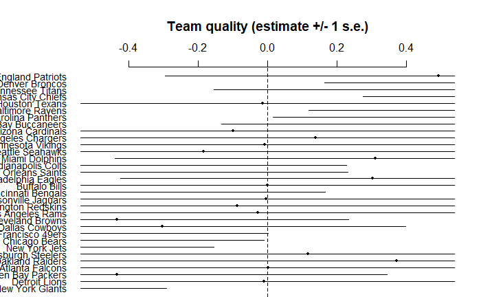

```r
library ("arm")
```

## Predictions

Do predictions in Stan using a `generated quantities` block, and bring over to R.

```r
pred_diffs <- colMeans(pred_chains)
```

```
Error in colMeans(pred_chains) : object 'pred_chains' not found
```

```r
upcoming_games %>%
  bind_cols(pred_home_win=pred_diff) -> upcoming_game_win
```

```
Error in eval_bare(dot$expr, dot$env) : object 'pred_diff' not found
```

```r
upcoming_games %>%
  bind_cols(data_frame(pred_home_win=pred_diff)) -> upcoming_game_win
```

```
Error in overscope_eval_next(overscope, expr) :
  object 'pred_diff' not found
```

# Home field advantage

I wrote an extension `nfl_model_pred_homeadv.stan` that basically adds a home field advantage, a $t_3$ distribution centered at 0 and sigma of 1, to all differences. It doesn’t require further data, but it will be interesting to look at it.

```r
fit2 <- stan("nfl_model_pred_homeadv.stan",data=data,iter=3000,warmup=1250,control=list(adapt_delta=0.95))
```

[output not shown]

## Team quality considering home field

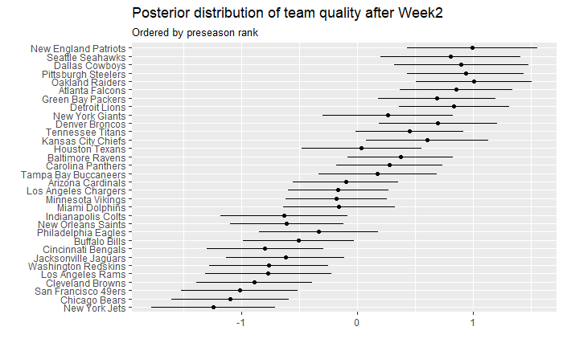

## What is the homefield advantage?

The homefield advantage can be explored by extracting the `home_adv` parameter and investigating its density.

```r
data_frame(home_adv=home_adv) %>%
  ggplot() +
  geom_density(aes(x=home_adv))
```

```
Error: stat_density requires the following missing aesthetics: x
```

```
Error: stat_density requires the following missing aesthetics: x
```

| home_adv |
| --- |

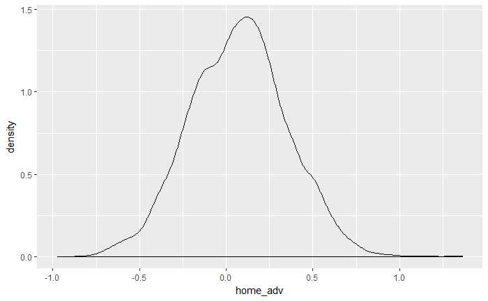

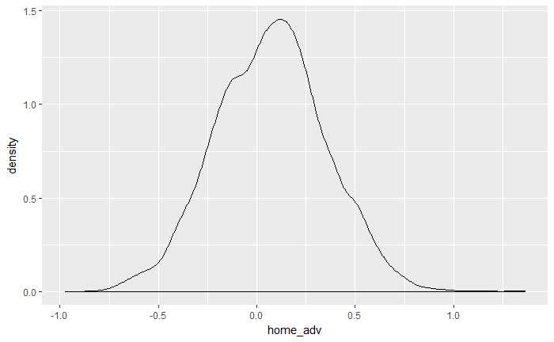

| n | home_adv_mean | home_adv_sd |
| --- | --- | --- |
| 7000 | 0.07 | 0.282 |

```r
data_frame(home_adv=home_adv) %>%
  ggplot(aes(x=home_adv)) +
  geom_density()
```

We expect home field advantage to be positive. A team playing at home can expect to add `home_adv` points to the spread vs. the visiting team. However, at the beginning of the season there may not be enough data to get a sensible `home_adv` estimate, and it will probably stay close to 0 a few weeks into the season.

## Who’s gonna win under home field advantage

```r
pred_chains2 <-  extract(fit2,"new_dif")$new_dif
pred_diffs2 <- colMeans(pred_chains2>0)
pred_spread2 <- colMeans(pred_chains2)
upcoming_games %>%
  bind_cols(data_frame(pred_home_win=pred_diffs2,pred_spread=pred_spread2)) %>%
  dplyr::select(home_team,visiting_team,pred_home_win,pred_spread) -> upcoming_game_win
upcoming_game_win %>%
  mutate(pred_home_win = sprintf("%3.1f%%",pred_home_win*100),
         pred_spread = sprintf("%5.2f",pred_spread))
```

| home_team | visiting_team | pred_home_win | pred_spread |
| --- | --- | --- | --- |
| Jacksonville Jaguars | Baltimore Ravens | 27.4% | -1.40 |
| Detroit Lions | Atlanta Falcons | 49.6% | -0.04 |
| Indianapolis Colts | Cleveland Browns | 55.8% | 0.34 |
| Chicago Bears | Pittsburgh Steelers | 11.7% | -3.59 |
| Carolina Panthers | New Orleans Saints | 70.9% | 1.35 |
| Philadelphia Eagles | New York Giants | 36.5% | -0.86 |
| Buffalo Bills | Denver Broncos | 24.0% | -1.81 |
| New York Jets | Miami Dolphins | 25.6% | -1.56 |
| New England Patriots | Houston Texans | 71.2% | 1.39 |
| Minnesota Vikings | Tampa Bay Buccaneers | 41.6% | -0.57 |

[output cut: 5 more lines]

# Injuries

This extends the model to include injuries in addition to home field advantage.

## Obtaining injury data

First, we get injuries by week. Fox Sports seems to have the most usable data on this (i.e. easiest to scrape), so use their site. Then we use everybody listed as Doubtful or Out as a proxy for the severity of injuries to a team.

| week | team_name | injuries |
| --- | --- | --- |
| 1 | Arizona Cardinals | 1 |
| 1 | Atlanta Falcons | 1 |
| 1 | Baltimore Ravens | 2 |
| 1 | Buffalo Bills | 2 |
| 1 | Carolina Panthers | 3 |
| 1 | Chicago Bears | 1 |
| 1 | Cincinnati Bengals | 2 |
| 1 | Cleveland Browns | 1 |
| 1 | Dallas Cowboys | 1 |
| 1 | Denver Broncos | 4 |

[output cut: 86 more lines]

Now we merge injury numbers by the NFL scores we obtained earlier.

```r
nfl_scores %>%
  left_join(injury_numbers,by=c("week"="week","visiting_team"="team_name")) %>%
  rename(visiting_injuries=injuries) %>%
  left_join(injury_numbers,by=c("week"="week","home_team"="team_name")) %>%
  rename(home_injuries=injuries) -> nfl_scores_injuries
nfl_scores_injuries
```

| week | visiting_team | visiting_score | home_team | home_score | visiting_injuries | home_injuries |
| --- | --- | --- | --- | --- | --- | --- |
| 1 | Kansas City Chiefs | 42 | New England Patriots | 27 | 2 | 1 |
| 1 | Pittsburgh Steelers | 21 | Cleveland Browns | 18 | 1 | 1 |
| 1 | Baltimore Ravens | 20 | Cincinnati Bengals | 0 | 2 | 2 |
| 1 | Atlanta Falcons | 23 | Chicago Bears | 17 | 1 | 1 |
| 1 | Philadelphia Eagles | 30 | Washington Redskins | 17 | 0 | 0 |
| 1 | New York Jets | 12 | Buffalo Bills | 21 | 2 | 2 |
| 1 | Oakland Raiders | 26 | Tennessee Titans | 16 | 2 | 1 |
| 1 | Jacksonville Jaguars | 29 | Houston Texans | 7 | 0 | 2 |
| 1 | Arizona Cardinals | 23 | Detroit Lions | 35 | 1 | 0 |
| 1 | Indianapolis Colts | 9 | Los Angeles Rams | 46 | 5 | 0 |

[output cut: 21 more lines]

Next, we need to add the injuries to upcoming games.

| visiting_team | home_team | visiting_injuries | home_injuries |
| --- | --- | --- | --- |
| Baltimore Ravens | Jacksonville Jaguars | 5 | 2 |
| Atlanta Falcons | Detroit Lions | 4 | 3 |
| Cleveland Browns | Indianapolis Colts | 5 | 7 |
| Pittsburgh Steelers | Chicago Bears | 2 | 4 |
| New Orleans Saints | Carolina Panthers | 6 | 4 |
| New York Giants | Philadelphia Eagles | 4 | 5 |
| Denver Broncos | Buffalo Bills | 2 | 6 |
| Miami Dolphins | New York Jets | 2 | 6 |
| Houston Texans | New England Patriots | 4 | 3 |
| Tampa Bay Buccaneers | Minnesota Vikings | 5 | 1 |

[output cut: 6 more lines]

## Modeling

Now we’re ready to fit the model in `Stan`. Home field advantage has a prior of normal with 0 mean and standard deviation of 3. Injury has a prior of normal with 0 mean and standard deviation of 1.

```r
teams <- as_vector(preseason_ranks %>% dplyr::select(team))
nteams <- length(teams)
prior_score <- rev(1:nteams)
prior_score <- (prior_score-mean(prior_score)) / (2*sd(prior_score))
ngames <- nrow(nfl_scores_injuries)
team1 <- match(as_vector(nfl_scores_injuries %>% dplyr::select(home_team)),teams)
score1 <- as.numeric(as_vector(nfl_scores_injuries %>% dplyr::select(home_score)))
injury1 <- as.numeric(as_vector(nfl_scores_injuries %>% dplyr::select(home_injuries)))
team2 <- match(as_vector(nfl_scores_injuries %>% dplyr::select(visiting_team)),teams)
score2 <- as.numeric(as_vector(nfl_scores_injuries %>% dplyr::select(visiting_score)))
injury2 <- as.numeric(as_vector(nfl_scores_injuries %>% dplyr::select(visiting_injuries)))
df <- 7
# for predictive probabilities
newgames <- nrow(upcoming_games_injuries)
newteam1 <- match(upcoming_games_injuries$home_team,teams)
newteam2 <- match(upcoming_games_injuries$visiting_team,teams)
newinjury1 <- as.numeric(as_vector(upcoming_games_injuries %>% dplyr::select(home_injuries)))
newinjury2 <- as.numeric(as_vector(upcoming_games_injuries %>% dplyr::select(visiting_injuries)))
data <- c("nteams","ngames","team1","score1","team2","score2","prior_score","df",
          "injury1","injury2","newgames","newteam1","newteam2","newinjury1","newinjury2")
fit3 <- stan("nfl_homefield_inj.stan",data=data,iter=3000,warmup=1250,control=list(adapt_delta=0.95))
```

[output not shown]

## Team quality considering home field and injuries

[figure not shown]

[figure not shown]

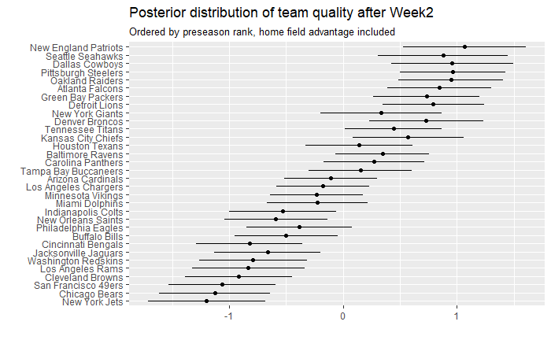

```r
sims3 <- rstan::extract(fit3)
a_sims3 <- sims3$a
a_hat3 <- colMeans(a_sims3)
a_se3 <- sqrt(colVars(a_sims3))
data_frame(teams=factor(rev(teams),ordered=TRUE),quality_mean=rev(a_hat3),quality_se=rev(a_se3),
           preseason_rank = 32:1) -> post3
post3 %>%
  ggplot(aes(x=reorder(teams,rev(preseason_rank)))) +
  scale_x_discrete() +
  geom_segment(aes(xend=teams,y=quality_mean-quality_se,yend=quality_mean+quality_se)) +
  geom_point(aes(y=quality_mean)) +
  coord_flip() +
  labs(x = "",y="",title=paste0("Posterior distribution of team quality after Week",this_week-1),
       subtitle="Ordered by preseason rank, home field advantage included")
```

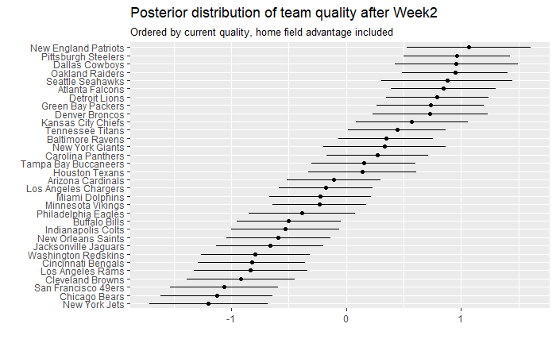

```r
post3 %>%
  ggplot(aes(x=fct_reorder(teams,quality_mean))) +
  scale_x_discrete() +
  geom_segment(aes(xend=teams,y=quality_mean-quality_se,
                   yend=quality_mean+quality_se)) +
  geom_point(aes(y=quality_mean)) +
  coord_flip() +
  labs(x = "",y="",title=paste0("Posterior distribution of team quality after Week",this_week-1),
       subtitle="Ordered by current quality, home field advantage included")
```

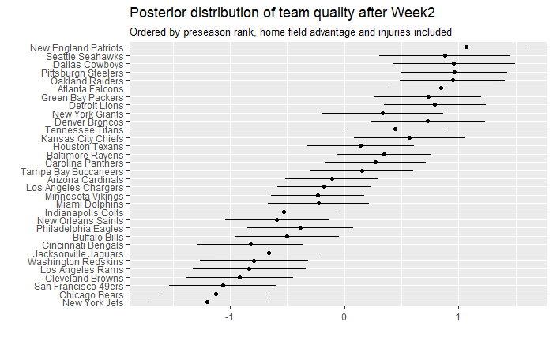

```r
sims3 <- rstan::extract(fit3)
a_sims3 <- sims3$a
a_hat3 <- colMeans(a_sims3)
a_se3 <- sqrt(colVars(a_sims3))
data_frame(teams=factor(rev(teams),ordered=TRUE),quality_mean=rev(a_hat3),quality_se=rev(a_se3),
           preseason_rank = 32:1) -> post3
post3 %>%
  ggplot(aes(x=reorder(teams,rev(preseason_rank)))) +
  scale_x_discrete() +
  geom_segment(aes(xend=teams,y=quality_mean-quality_se,yend=quality_mean+quality_se)) +
  geom_point(aes(y=quality_mean)) +
  coord_flip() +
  labs(x = "",y="",title=paste0("Posterior distribution of team quality after Week",this_week-1),
       subtitle="Ordered by preseason rank, home field advantage and injuries included")
```

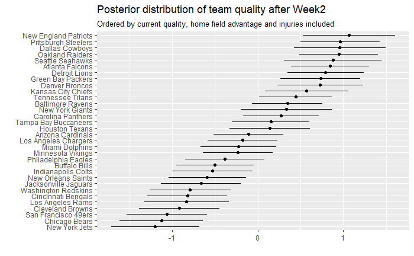

```r
post3 %>%
  ggplot(aes(x=fct_reorder(teams,quality_mean))) +
  scale_x_discrete() +
  geom_segment(aes(xend=teams,y=quality_mean-quality_se,
                   yend=quality_mean+quality_se)) +
  geom_point(aes(y=quality_mean)) +
  coord_flip() +
  labs(x = "",y="",title=paste0("Posterior distribution of team quality after Week",this_week-1),
       subtitle="Ordered by current quality, home field advantage and injuries included")
```

## What is the home field advantage in model with injuries

```r
home_adv3 <- rstan::extract(fit3,"home_adv")
data_frame(home_adv=home_adv$home_adv3) -> home_adv_df3
```

```
Error: Column `home_adv` must be a 1d atomic vector or a list
```

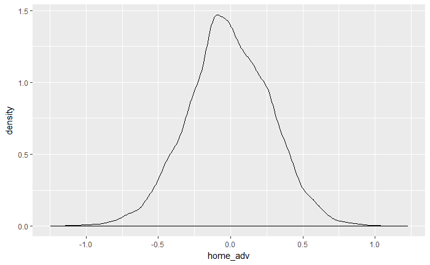

```r
home_adv3 <- rstan::extract(fit3,"home_adv")
data_frame(home_adv=home_adv3$home_adv) -> home_adv_df3
home_adv_df3 %>%
  ggplot(aes(x=home_adv)) +
  geom_density()
```

```r
home_adv_df3 %>%
  summarize(n=n(),home_adv_mean = sprintf("%4.2f",mean(home_adv)),home_adv_sd=sprintf("%5.3f",sd(home_adv)))
```

| n | home_adv_mean | home_adv_sd |
| --- | --- | --- |
| 12000 | -0.01 | 0.288 |

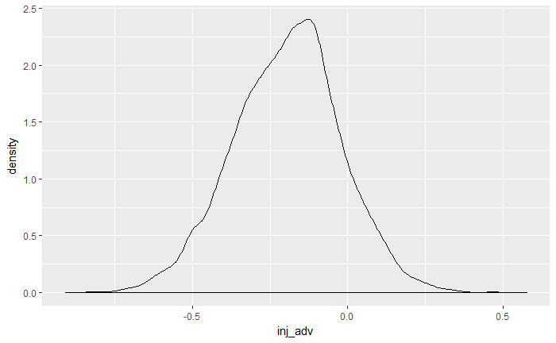

```r
inj_adv3 <- rstan::extract(fit3,"inj_adv")
data_frame(inj_adv=inj_adv3$inj_adv) -> inj_adv_df3
inj_adv_df3 %>%
  ggplot(aes(x=inj_adv)) +
  geom_density()
```

```r
inj_adv_df3 %>%
  summarize(n=n(),inj_adv_mean = sprintf("%4.2f",mean(inj_adv)),inj_adv_sd=sprintf("%5.3f",sd(inj_adv)))
```

| n | inj_adv_mean | inj_adv_sd |
| --- | --- | --- |
| 12000 | -0.20 | 0.173 |

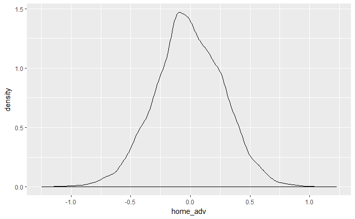

```r
home_adv3 <- rstan::extract(fit3,"home_adv")
data_frame(home_adv=home_adv3$home_adv) -> home_adv_df3
home_adv_df3 %>%
  ggplot(aes(x=home_adv)) +
  geom_density()
```

```r
home_adv_df3 %>%
  summarize(n=n(),home_adv_mean = sprintf("%4.2f",mean(home_adv)),home_adv_sd=sprintf("%5.3f",sd(home_adv)))
```

| n | home_adv_mean | home_adv_sd |
| --- | --- | --- |
| 12000 | -0.01 | 0.288 |

As it will take a few weeks for the model to become stable, we expect home field advantage estimates to be around 0, especially with the injury parameter added. It’s possible that the model doesn’t quite yet know how to assign “blame” to home field advantage vs. injuries. Eventually, we expect it to be positive.

## What is the injury advantage

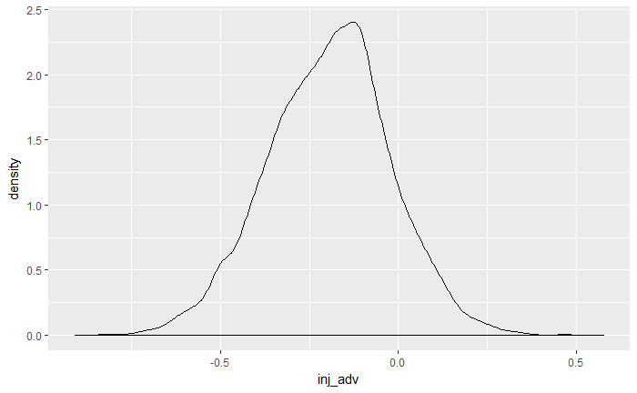

```r
inj_adv3 <- rstan::extract(fit3,"inj_adv")
data_frame(inj_adv=inj_adv3$inj_adv) -> inj_adv_df3
inj_adv_df3 %>%
  ggplot(aes(x=inj_adv)) +
  geom_density()
```

```r
inj_adv_df3 %>%
  summarize(n=n(),inj_adv_mean = sprintf("%4.2f",mean(inj_adv)),inj_adv_sd=sprintf("%5.3f",sd(inj_adv)))
```

| n | inj_adv_mean | inj_adv_sd |
| --- | --- | --- |
| 12000 | -0.20 | 0.173 |

We expect injury advantage to be negative. In the model, this factor is multiplied by the difference in injured players between the home team and visiting team and added to the mean point spread of the distribution. So for every player injured on the home team more than the visiting team, we can expect the home team to have a spread of `inj_adv` fewer points (or lose by `inj_adv` more points).

## Who’s gonna win?

```r
pred_chains <-  extract(fit3,"new_dif")$new_dif
pred_diffs <- colMeans(pred_chains>0)
pred_spread <- colMeans(pred_chains)
upcoming_games %>%
  bind_cols(data_frame(pred_home_win=pred_diffs,pred_spread=pred_spread)) %>%
  dplyr::select(home_team,visiting_team,pred_home_win,pred_spread) -> upcoming_game_win
upcoming_game_win %>%
  mutate(pred_home_win = sprintf("%3.1f%%",pred_home_win*100),
         pred_spread = sprintf("%5.2f",pred_spread))
```

| home_team | visiting_team | pred_home_win | pred_spread |
| --- | --- | --- | --- |
| Jacksonville Jaguars | Baltimore Ravens | 39.1% | -0.63 |
| Detroit Lions | Atlanta Falcons | 53.3% | 0.14 |
| Indianapolis Colts | Cleveland Browns | 49.8% | -0.00 |
| Chicago Bears | Pittsburgh Steelers | 9.0% | -4.77 |
| Carolina Panthers | New Orleans Saints | 77.1% | 1.93 |
| Philadelphia Eagles | New York Giants | 30.0% | -1.38 |
| Buffalo Bills | Denver Broncos | 14.6% | -3.62 |
| New York Jets | Miami Dolphins | 16.7% | -3.06 |
| New England Patriots | Houston Texans | 74.6% | 1.67 |
| Minnesota Vikings | Tampa Bay Buccaneers | 59.2% | 0.57 |

[output cut: 6 more lines]

# References

This was inspired by the soccer example from [Andy Gelman’s Stan talk](https://www.youtube.com/watch?v=T1gYvX5c2sM&t=3310s). Code is [here](http://andrewgelman.com/2014/07/13/stan-analyzes-world-cup-data/).